# 3DTubularVoronoi.

It is recommended to read the user manual before executing.

## Packages

Install necessary packages.

# 1/ Single simulation

## Parameters

Parameters for single simulation. Edit the values.

```r
params = list(
  seed = 1, # randomness
  n_steps = 50, # simulation steps
  n_cells = 100, # number of cells
  n_layers = 10, # numbers of layers (min 3)
  apical_rad = 5/(2*pi), # apical radius
  ratio_rad = 2.5, # ratio between apical and basal radius
  cyl_length = 20, # cylinder length
  gamma = 0.15, #3  contractility
  lambda = 0.04, # adhesion
  #kappa = 1 cause adimentionality (elasticity)
  beta = 100, #constant involved in jumps because of perturbations
  s0_ratio = 1 # characteristic ratio between the acztual radius and apical radius
  )
```

## Execution

Execute a single simulation

```r
PATH_MODEL = "tubular_simulations_source/model_execution.R"
source(PATH_MODEL)
start.time <- Sys.time()
simulation <- perform_simulations(algorithm="static",parameters=params)
```

## Loading results

Load previous results. Edit *fileName*. ATTENTION: the dataframe *simulation* might be overwritten.

```r
fileName <- "results/static/results_simulation_25_01_31.RData"

# DO NOT MODIFY
PATH_FUNCTIONS = "tubular_simulations_source/save_simulation_results.R"
source(PATH_FUNCTIONS)
simulation <- load_results(fileName)
result_alg <- simulation$results
parameters <- simulation$parameters
algorithm <- simulation$algorithm
hist_points = result_alg$points_evolution
hist_energy = result_alg$energy_evolution
```

## Tube visualization

Save the tessellation of a selected iteration. Edit *saveIteration*. The first iteration is 0 and the last one is *parameters$n_steps*.

```r
saveIteration <- parameters$n_steps

# DO NOT MODIFY
library(dplyr) # to do the filtering operation in the dataframe
dir.create(file.path("saved_tessellations/"), showWarnings = FALSE)
PATH_FUNCTIONS = "tubular_simulations_source/save_utils.R"
source(PATH_FUNCTIONS)
points <- filter(result_alg[[1]], Iteration == saveIteration)
pts_info = save_tessellation_layers(points, n = parameters$n_cells, RadiusA =parameters$apical_rad, Ratio = parameters$ratio_rad,cyl_length = parameters$cyl_length, Layers = parameters$n_layers, filename = paste0("saved_tessellations/saved_tessellation_iteration_",saveIteration,".csv"))
```

## Data analysis - single simulation

### a/ Energy levels plots

Plot the energies over time, per cell or per layer. To note that *hist_energy* is equivalent to *enerhist_total$toten*.

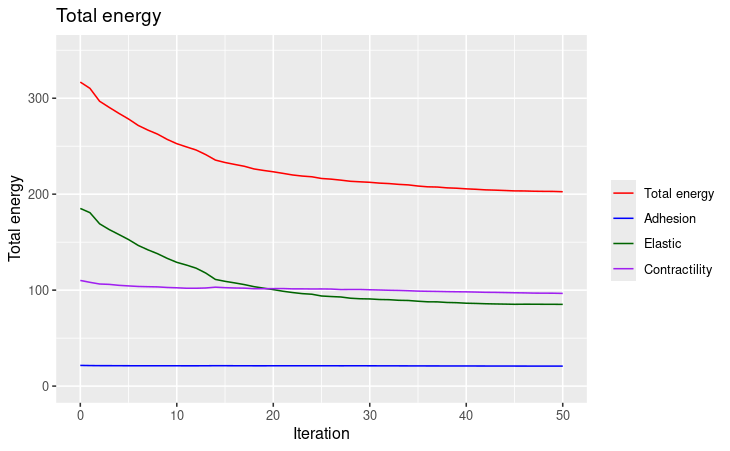

```r
PATH_ANALYSIS = "tubular_simulations_source/source_analysis.R"
source(PATH_ANALYSIS)
# Total energy of the tissue
enerhist_total <- energy_analisis_1sim(hist_points, it = parameters$n_steps, lay = parameters$n_layers, n = parameters$n_cells,total=TRUE)
plot_energyss(enerhist_total,total=TRUE)
```

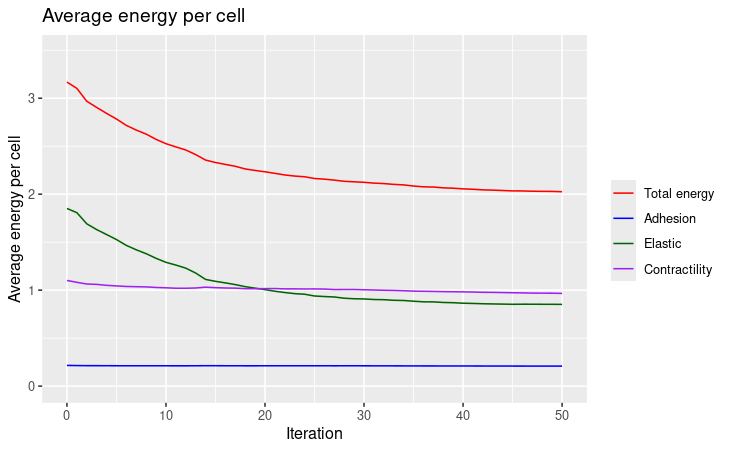

```r
# Average energies over time per cell
enerhist_total_percell <- energy_analisis_1sim(hist_points, it = parameters$n_steps, lay = parameters$n_layers, n = parameters$n_cells)
plot_energyss(enerhist_total_percell)
```

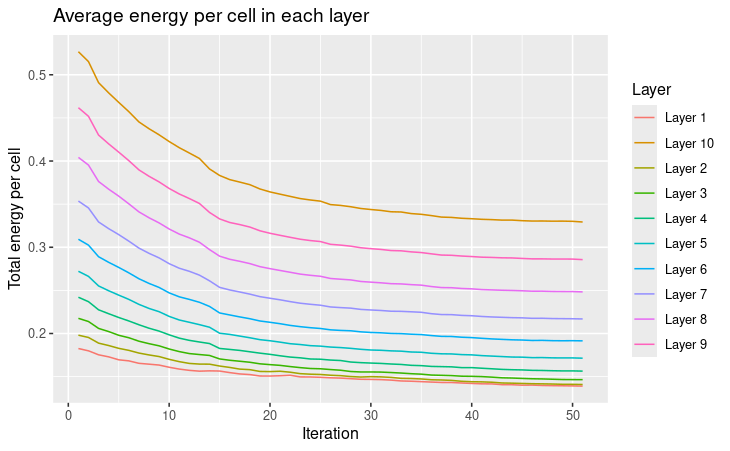

```r
# Average energy over time per cell in each layer
hist_layers <- energy_layers_sim1(histpts = hist_points, it = parameters$n_steps, Lay = parameters$n_layers, n = parameters$n_cells)
plot_energy_decomp(hist_layers)
```

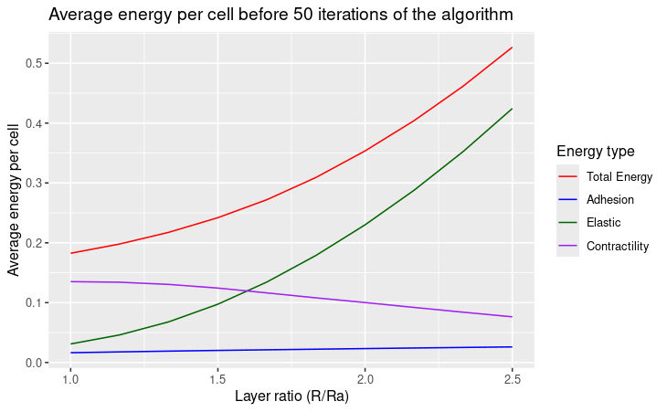

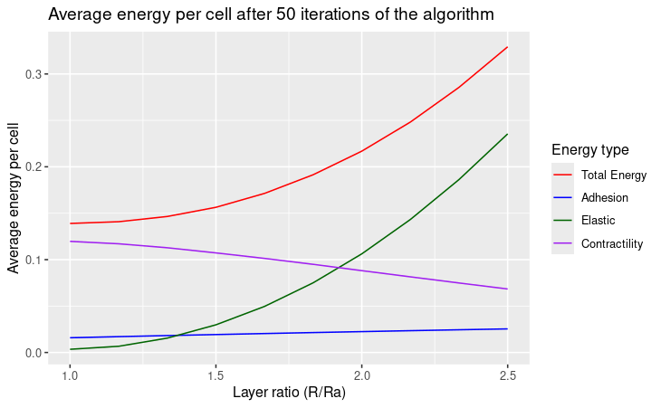

```r
# First and last frame
hist_layers_firstlast <- energy_analysis_nobend(histpts = hist_points, it = parameters$n_steps, n = parameters$n_cells, Lay = parameters$n_layers)
```

### b/ Typology

Number of edges and percentage of scutoids. Select the iteration you want to study by editing *selectedIteration*.

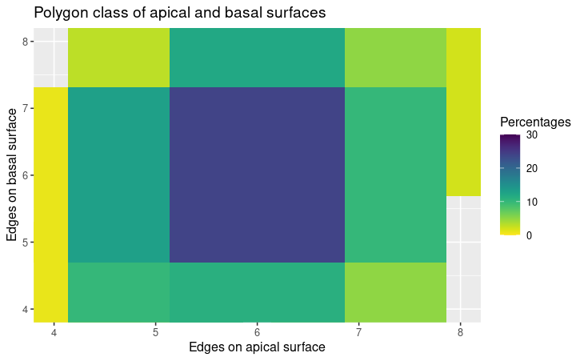

```r
selectedIteration =  parameters$n_steps

# DO NOT MODIFY
PATH_ANALYSIS = "tubular_simulations_source/source_simulation_analysis.R"
source(PATH_ANALYSIS)
# Percentages of cells depending on the number of edges
points <- filter(result_alg$points_evolution, Iteration == selectedIteration)
scutoids_analysis_oneiter(points$x,points$y,(parameters$ratio_rad)*points$x,points$y,ratio=parameters$ratio_rad,ap_rad = parameters$apical_rad, n = parameters$n_cells,cylen = parameters$cyl_length)
```

```
[1] 50
[1] "Plot saved:Number of neighbors apical iteration 50"
[1] "Plot saved:Cells area apical iteration 50"
```

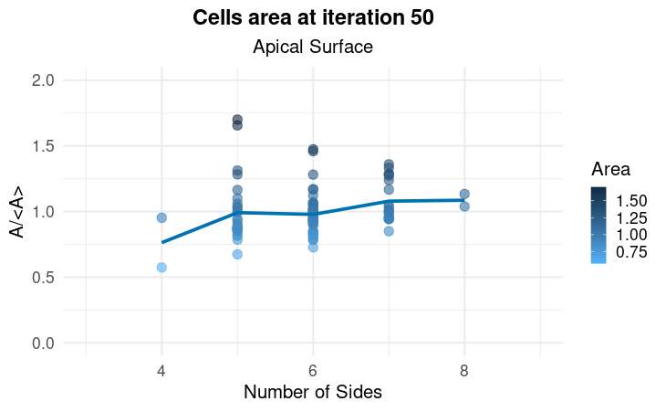

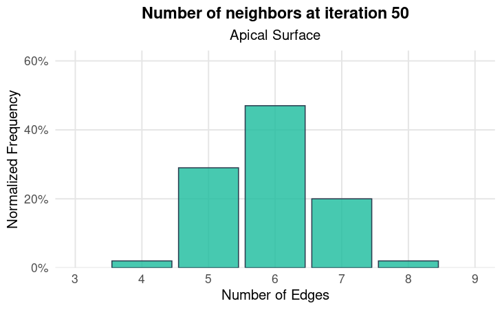

```r
# Average number of neighbors
edgear <- funaux2simDOUBLE(result_alg$points_evolution,ps=1,n=parameters$n_cells, cylen = parameters$cyl_length,apical_radius = parameters$apical_rad,it=parameters$n_steps)
#apical area
edgear_filtA = dplyr::filter(edgear[[1]], Iteration == selectedIteration)
stationarylewisApical(edgear_filtA[1:parameters$n_cells,c(1,2,3)],it=selectedIteration)
```

```
[1] "Plot saved:Number of neighbors basal iteration 50"
[1] "Plot saved:Cells area basal iteration 50"
```

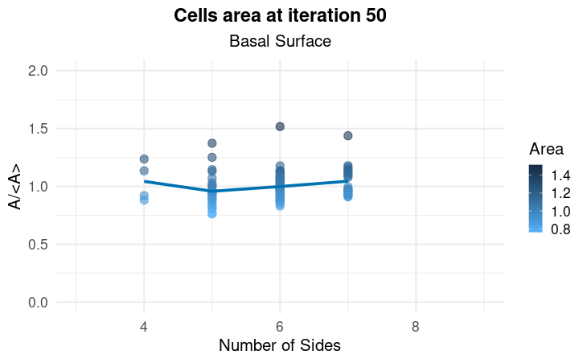

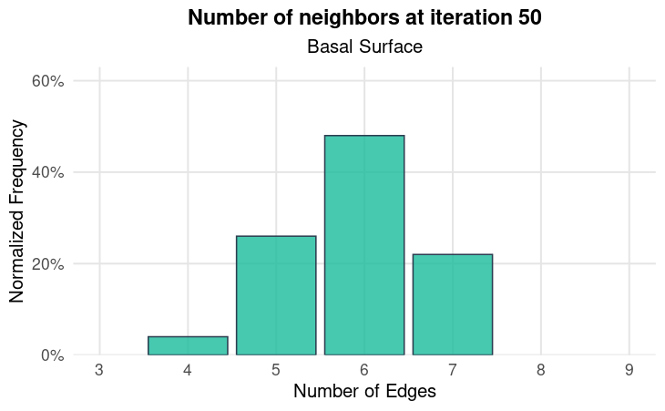

```r
#basal area
edgear_filtB = dplyr::filter(edgear[[2]], Iteration == selectedIteration)
stationarylewisBasal(edgear_filtB[1:parameters$n_cells,c(1,2,3)],it=selectedIteration)
```

| Iteration | perc_sc |
| --- | --- |
| 0 | 98 |
| 1 | 98 |
| 2 | 98 |
| 3 | 97 |
| 4 | 96 |
| 5 | 96 |
| 6 | 96 |
| 7 | 98 |
| 8 | 97 |
| 9 | 97 |

[output cut: 41 more lines]

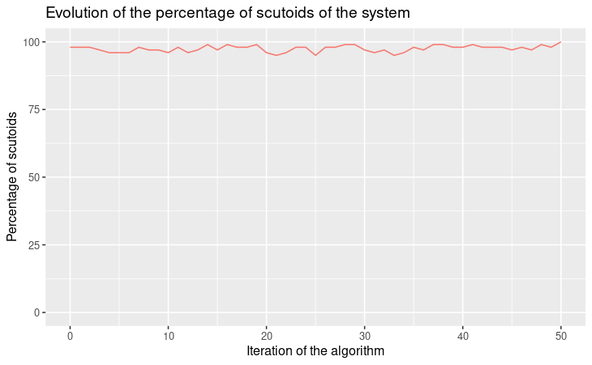

```r
# Scutoids percentage over time
scutoids_percr(hist_points,ratio=parameters$ratio_rad,ap_rad = parameters$apical_rad, n = parameters$n_cells,cylen = parameters$cyl_length,it=parameters$n_steps)
```

# 2/ Parallelization

## Execution

Execute multiple simulations at the same time using different seeds (random initial conditions). Choose the number of simulations *N_SIM* and edit the list of parameters.

## Loading results

Load pre-existing results. Edit the file name and the number *N_SIM* of simulations to import. ATTENTION: the dataframe *par_results* might be overwritten.

```r
fileName <- "results/parallel/results_simulation_25_01_31_"
N_SIM = 10

# DO NOT MODIFY
PATH_FUNCTIONS = "tubular_simulations_source/save_simulation_results.R"
source(PATH_FUNCTIONS)
par_results <- NULL
for(i in 1:N_SIM){
  filename <- paste0(fileName,i,".RData")
  # Extract
  simulation_i <- load_results(filename)
  results_i <- simulation_i$results
  parameters_i <- simulation_i$parameters
  algorithm_i <- simulation_i$algorithm
  # Build the array
  par_results <- rbind(par_results, list(results = results_i, parameters = parameters_i, algorithm = algorithm_i))}
par_parameters <- par_results[[1,2]]
```

## Tube visualization

Save the tessellation of a selected iteration and simulation. Edit *saveIteration* and *saveSimulation* The first iteration is 0 and the last one is *par_parameters$n_steps*.

```r
saveIteration <- par_parameters$n_steps
saveSimulation <- 2

# DO NOT MODIFY
library(dplyr) # to do the filtering operation in the dataframe
dir.create(file.path("saved_tessellations/"), showWarnings = FALSE)
PATH_FUNCTIONS = "tubular_simulations_source/save_utils.R"
source(PATH_FUNCTIONS)
points <- filter(par_results[[saveSimulation]]$points_evolution, Iteration == saveIteration)
pts_info = save_tessellation_layers(points, n = par_parameters$n_cells, RadiusA = par_parameters$apical_rad, Ratio = par_parameters$ratio_rad,
                                     cyl_length = parameters$cyl_length, Layers = parameters$n_layers,filename = paste0("saved_tessellations/saved_tessellation_iteration_",saveIteration,".csv"))
```

## Data analysis - Parallel

### a/ Energy levels plots

Average tissues energies.

```
[1] "Plot saved:Average total energies.svg"
```

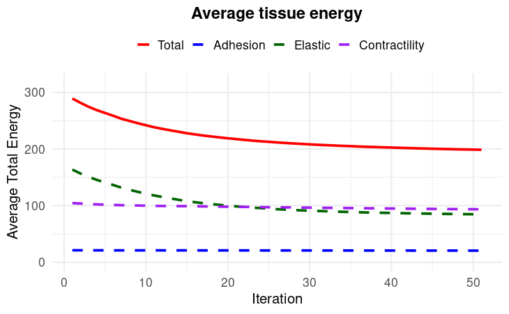

```r
PATH_ANALYSIS = "tubular_simulations_source/source_simulation_analysis.R"
source(PATH_ANALYSIS)
# Average energies
enerhist_average <- energy_analisis_averages_par(par_results, it = par_parameters$n_steps, lay = par_parameters$n_layers, n = par_parameters$n_cells,rad_coef = par_parameters$ratio_rad,Radius = par_parameters$apical_rad,cylen = par_parameters$cyl_length,gamma = par_parameters$gamma,lambda=par_parameters$lambda,s0 = par_parameters$s0_ratio)
```

```r
# Average regression of the total energy
#adjsim(par_results,nsim=N_SIM,it=par_parameters$n_steps)
```

### b/ Typology

Number of edges and relative cell area in the apical and basal area. Edit *selectedIteration* to select the iteration. The first one is 0 and the last one is *par_parameters$n_steps*.

```
[1] 50
[1] "Plot saved:Number of neighbors apical iteration 50"
[1] "Plot saved:Cells area apical iteration 50"
```

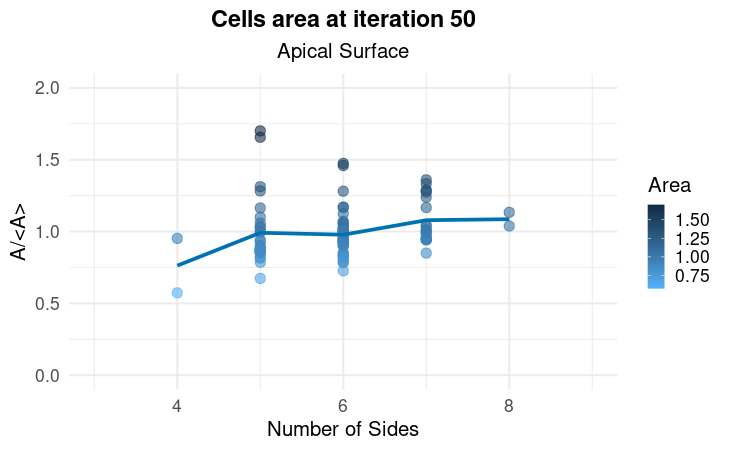

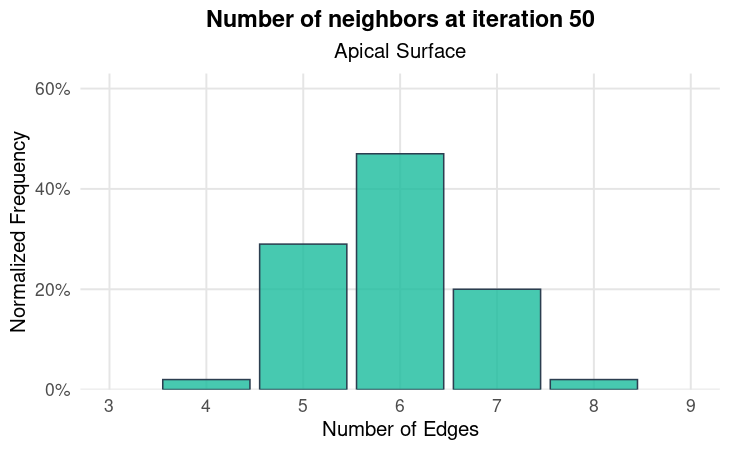

```r
selectedIteration =  par_parameters$n_steps

# DO NOT MODIFY
PATH_SIMANALYSIS = "tubular_simulations_source/source_simulation_analysis.R"
source(PATH_SIMANALYSIS)
# Reorganize all the simulations by iteration
resord <- ord(par_results, iter = par_parameters$n_steps, n=par_parameters$n_cells, sim = N_SIM)
# Average number of neighbors in basal surface per frame
edgearsim <- funaux2simDOUBLE(resord,n=par_parameters$n_cells,ps=N_SIM,cylen = par_parameters$cyl_length, apical_radius = par_parameters$apical_rad, Ratio = par_parameters$ratio_rad,it=par_parameters$n_steps)
# Average number of neighbors in the apical area
edgear_filteredA <- dplyr::filter(edgearsim[[1]], Iteration == selectedIteration)
stationarylewisApical(edgear_filteredA[1:(par_parameters$n_cells),c(1,2,3)],it = selectedIteration)
```

```
[1] "Plot saved:Number of neighbors basal iteration 50"
[1] "Plot saved:Cells area basal iteration 50"
```

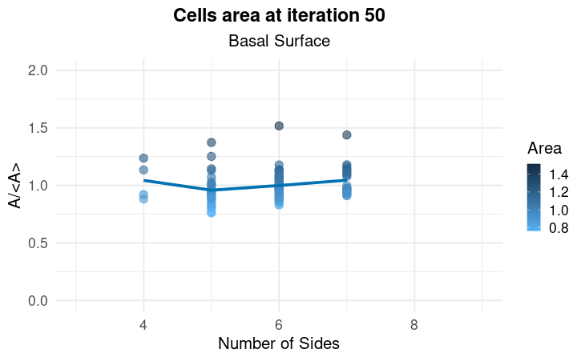

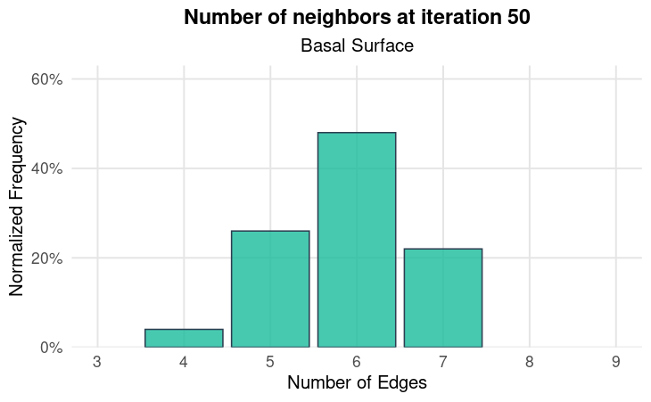

```r
# Average number of neighbors in the basal area
edgear_filteredB <- dplyr::filter(edgearsim[[2]], Iteration == selectedIteration)
stationarylewisBasal(edgear_filteredB[1:(par_parameters$n_cells),c(1,2,3)],it = selectedIteration)
```

```
[1] "Plot saved:Edges at iteration 50"
```

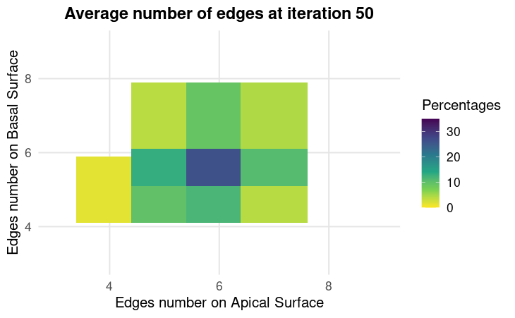

```r
# Scutoids table percentages
scutoids_analysis_simulations(par_results, it = selectedIteration , sim = N_SIM, n = par_parameters$n_cells,cylen = par_parameters$cyl_length,ap_rad = par_parameters$apical_rad, Ratio = par_parameters$ratio)
```

```
[1] "Average percentage of scutoids:  94.0274509803922"
```

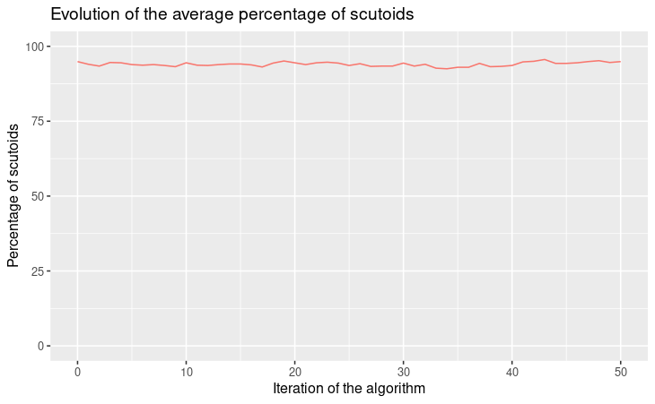

```r
# Scutoids percentage over time
scutoids_percr_simulations_par(par_results, n=par_parameters$n_cells, sim=N_SIM, it=  par_parameters$n_steps,ap_rad = par_parameters$apical_rad, cylen=par_parameters$cyl_length,ratio=par_parameters$ratio_rad)
```